# Design evaluation and optimization with PopED, babelmixr2 and nlmixr2 Hands-on 2

ACoP15 2024 - Using Past Models to Bridge to Open Models and Open Science Using nlmixr2

Theodoros (Theo) Papathanasiou

Matt Fidler

On behalf of the nlmixr2 development team

14 November 2024

[figure not shown]

# Overview

This tutorial was based on the PopED examples that were previously created by Martin Fink, Giulia Lestini, and Andrew Hooker. All classical PopED examples can be found under the standard PopED installation folder, or by following the file path obtained by the command: system.file(“examples”, package=“PopED”).

Below, we provide links to the PopED software website, the babelmixr2 and PopED blog post.

**PopED** [https://andrewhooker.github.io/PopED/](https://urldefense.com/v3/__https://andrewhooker.github.io/PopED/__;!!N3hqHg43uw!t1kb9mDZrvf4HFlVr9eweUX-mzhEEu9hNbzjA63hsk4rRibEaDdh8D8hQgGpH09kPR0lPqX3tBzWtF4RZgnpYdc8gqpX$) **babelmixr2 and PopED blog** [https://blog.nlmixr2.org/blog/2024-11-06-poped/](https://urldefense.com/v3/__https://blog.nlmixr2.org/blog/2024-11-06-poped/__;!!N3hqHg43uw!t1kb9mDZrvf4HFlVr9eweUX-mzhEEu9hNbzjA63hsk4rRibEaDdh8D8hQgGpH09kPR0lPqX3tBzWtF4RZgnpYXmc8E3x$)

# Example: PKPD model with analytical solution

## Classical PopED implementation

When working with PopED, the user is expected to define three user defined functions. These are: - ff_fun: Function describing the structural model. e.g. ff.PK.1.comp.oral.md.KE. - fg_fun: Function describing the parameter model. e.g. parameter.model. - fError_fun: Function describing the residual error model. e.g. feps.prop.

Below, we define the three user functions for a PK problem with an analytical solution: The problem we are working with, is a simple one compartment distribution model with first order absorption.

### Structural model function

```r
##-- Model: One comp first order absorption + inhibitory imax
## -- works for both mutiple and single dosing
ff <- function(model_switch,xt,parameters,poped.db){
  with(as.list(parameters),{

    y=xt
    MS <- model_switch

    # PK model
    N = floor(xt/TAU)+1
    CONC=(DOSE*Favail/V)*(KA/(KA - CL/V)) *
      (exp(-CL/V * (xt - (N - 1) * TAU)) * (1 - exp(-N * CL/V * TAU))/(1 - exp(-CL/V * TAU)) -
         exp(-KA * (xt - (N - 1) * TAU)) * (1 - exp(-N * KA * TAU))/(1 - exp(-KA * TAU)))

    # PD model
    EFF = E0*(1 - CONC*IMAX/(IC50 + CONC))

    y[MS==1] = CONC[MS==1]
    y[MS==2] = EFF[MS==2]

    return(list( y= y,poped.db=poped.db))
  })
}
```

### Parameter function

```r
# parameter definition function
# names match parameters in function ff
# PopED expects the bpop[] notation for fixed effects, the b[] notation for random effects and the a[] notation for any parameter that we are interested to evaluate or optimize over.
## -- parameter definition function
sfg <- function(x,a,bpop,b,bocc){
  parameters=c( V=bpop[1]*exp(b[1]),
                KA=bpop[2]*exp(b[2]),
                CL=bpop[3]*exp(b[3]),
                Favail=bpop[4],
                DOSE=a[1],
                TAU = a[2],
                E0=bpop[5]*exp(b[4]),
                IMAX=bpop[6],
                IC50=bpop[7])
  return( parameters )
}
```

### Residual unexplained variablity (RUV) function

```r
# Residual unexplained variablity (RUV) function
# In this example, the additive and proportional residual errors are defined explicitly, but there are some shorthand functions available
# Notice that the user needs to define a "code switch" to let PopED know that we are working with two models

## -- Residual Error function
feps <- function(model_switch,xt,parameters,epsi,poped.db){
  returnArgs <- ff(model_switch,xt,parameters,poped.db)
  y <- returnArgs[[1]]
  poped.db <- returnArgs[[2]]

  MS <- model_switch

  pk.dv <- y*(1+epsi[,1])+epsi[,2]
  pd.dv <-  y*(1+epsi[,3])+epsi[,4]

  y[MS==1] = pk.dv[MS==1]
  y[MS==2] = pd.dv[MS==2]

  return(list( y= y,poped.db =poped.db ))
}
```

### Design and design space definition

```r
# Define design and design space
poped.db <- create.poped.database(
            # Definition of the user defined functions
      ff_fun="ff",
      fError_fun="feps",
      fg_fun="sfg",

      # Definition of the fixed effect, random effects and error parameters,
      # and if they are fixed or not
      bpop=c(V=72.8,KA=0.25,CL=3.75,Favail=0.9,E0=1120,IMAX=0.807,IC50=0.0993),
      notfixed_bpop=c(1,1,1,0,1,1,1),
      d=c(V=0.09,KA=0.09,CL=0.25^2,E0=0.09),
      sigma=c(0.04,5e-6,0.09,100),
      notfixed_sigma=c(0,0,0,0),

      # Definition of the design group number, and the number or subjects per group
      groupsize=20,
      m=3,

      # Definition of the design space
      xt=c( 1,2,8,240,240,1,2,8,240,240),
      minxt=c(0,0,0,240,240,0,0,0,240,240),
      maxxt=c(10,10,10,248,248,10,10,10,248,248),
      discrete_xt = list(0:248),
      G_xt=c(1,2,3,4,5,1,2,3,4,5),
      bUseGrouped_xt=1,
      model_switch=c(1,1,1,1,1,2,2,2,2,2),
      a=list(c(DOSE=20,TAU=24),c(DOSE=40, TAU=24),c(DOSE=0, TAU=24)),
      maxa=c(DOSE=200,TAU=40),
      mina=c(DOSE=0,TAU=2),
      ourzero=0)
```

It is always helpful to plot out the design and the predictions that were defined for the construction of th PopED database. Thankfully, PopED has some readily available functions to aid with plotting

### Plot model predictions

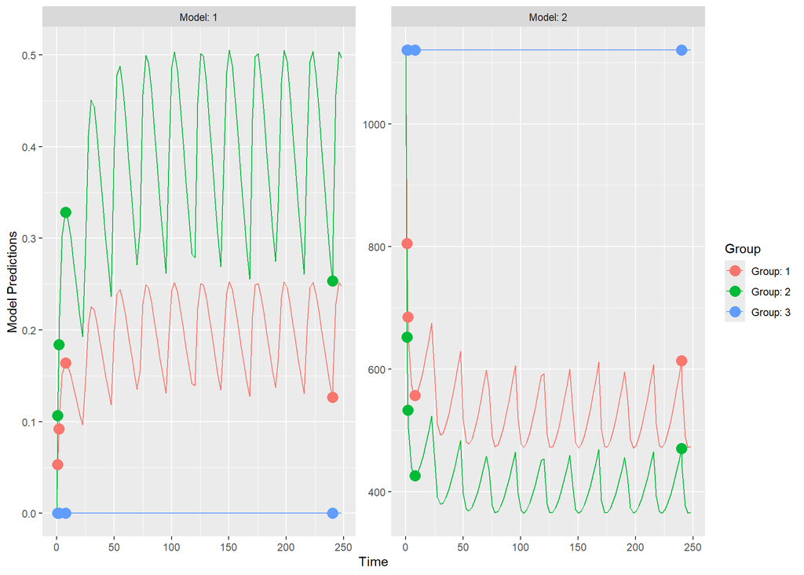

```r
##  create plot of model without variability
plot_model_prediction(poped.db,facet_scales="free")
```

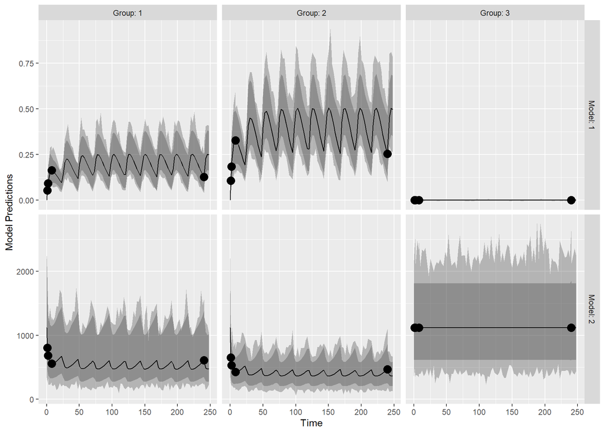

```r
##  create plot of model with variability
plot_model_prediction(poped.db,IPRED=T,DV=T,facet_scales="free",separate.groups=T)
```

What we want to do next, is a design evaluation to see what kind of information content we can expect from the design that we defined empirically.

### Design evaluation

```r
## evaluate initial design
evaluate_design(poped.db)
```

```
## $ofv
## [1] 41.91255
##
## $fim
##                  V            KA            CL            E0          IMAX
## V     5.382083e-02   -8.55463620  -0.115087642  8.293963e-05    -0.2103527
## KA   -8.554636e+00 3038.24916173 -14.769854387 -1.351406e-02   -69.0609684
## CL   -1.150876e-01  -14.76985439  39.394916550  3.372827e-03    -7.0857453
## E0    8.293963e-05   -0.01351406   0.003372827  4.403253e-04    -0.4017382
## IMAX -2.103527e-01  -69.06096842  -7.085745293 -4.017382e-01   821.9499022
## IC50  3.704090e-01    5.89767799  16.302391418  1.181080e+00 -1818.6277909
## d_V   0.000000e+00    0.00000000   0.000000000  0.000000e+00     0.0000000
## d_KA  0.000000e+00    0.00000000   0.000000000  0.000000e+00     0.0000000
## d_CL  0.000000e+00    0.00000000   0.000000000  0.000000e+00     0.0000000
## d_E0  0.000000e+00    0.00000000   0.000000000  0.000000e+00     0.0000000
##              IC50          d_V       d_KA        d_CL         d_E0
## V        0.370409    0.0000000   0.000000    0.000000    0.0000000
## KA       5.897678    0.0000000   0.000000    0.000000    0.0000000
## CL      16.302391    0.0000000   0.000000    0.000000    0.0000000
## E0       1.181080    0.0000000   0.000000    0.000000    0.0000000
## IMAX -1818.627791    0.0000000   0.000000    0.000000    0.0000000
## IC50  5030.928571    0.0000000   0.000000    0.000000    0.0000000
## d_V      0.000000 1017.0362159 303.009671   12.339375    0.5721641
## d_KA     0.000000  303.0096709 450.738936    2.396824    0.1852950
## d_CL     0.000000   12.3393753   2.396824 3836.326713    2.5117794
## d_E0     0.000000    0.5721641   0.185295    2.511779 2542.4091838
##
## $rse
##         V        KA        CL        E0      IMAX      IC50       d_V      d_KA
##  8.119842  9.968612  4.304635  7.076883  9.895340 39.478269 38.960998 58.523188
##      d_CL      d_E0
## 25.832775 22.036110
```

```r
# shrinkage(poped.db)
```

As a next step, we may want to try design optimization. By default, PopED with perform design optimization using the D-Optimality criterion. There are many more optimal design criteria, and they will not be covered in this course.

### Design optimization

#### Optimization of sample times

```r
# Optimization
output <- poped_optim(poped.db, opt_xt = T, parallel = F)
```

```r
# Evaluate optimization results
summary(output)
```

```
## ===============================================================================
## FINAL RESULTS
## Optimized Sampling Schedule
## Group 1: Model 1:      0      1     10    240    247
## Group 1: Model 2:      0      1     10    240    247
## Group 2: Model 1:      0      1     10    240    247
## Group 2: Model 2:      0      1     10    240    247
## Group 3: Model 1:      0      1     10    240    247
## Group 3: Model 2:      0      1     10    240    247
##
## OFV = 44.0498
##
## Efficiency:
##   ((exp(ofv_final) / exp(ofv_init))^(1/n_parameters)) = 1.2383
##
## Expected relative standard error
## (%RSE, rounded to nearest integer):
##    Parameter     Values   RSE_0   RSE
##            V       72.8       8     7
##           KA       0.25      10     9
##           CL       3.75       4     4
##           E0   1.12e+03       7     5
##         IMAX      0.807      10     6
##         IC50     0.0993      39    24
##          d_V       0.09      39    37
##         d_KA       0.09      59    58
##         d_CL     0.0625      26    27
##         d_E0       0.09      22    22
##
## Total running time: 44.57 seconds
```

```r
get_rse(output$FIM,output$poped.db)
```

```
##         V        KA        CL        E0      IMAX      IC50       d_V      d_KA
##  7.378959  9.224199  4.363698  4.923343  5.945328 24.169815 37.404330 58.360336
##      d_CL      d_E0
## 27.113994 22.005904
```

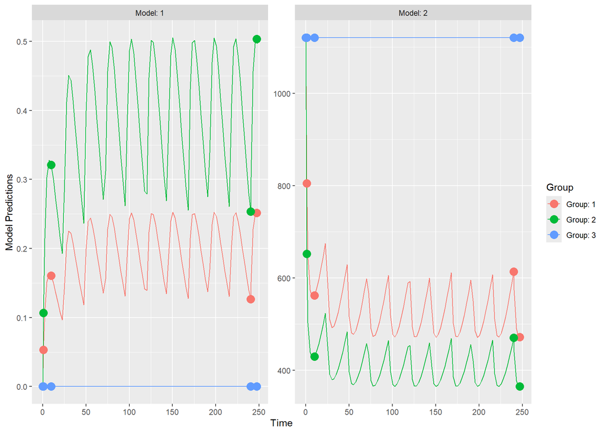

```r
plot_model_prediction(output$poped.db,facet_scales="free")
```

## babelmixr2/poped implementation

In this example, we demonstrate the general principles of the babelmixr2/poped user interface. Additional examples can be found in the examples folder, or following the link: [https://github.com/nlmixr2/babelmixr2/tree/main/inst/poped](https://urldefense.com/v3/__https://github.com/nlmixr2/babelmixr2/tree/main/inst/poped__;!!N3hqHg43uw!t1kb9mDZrvf4HFlVr9eweUX-mzhEEu9hNbzjA63hsk4rRibEaDdh8D8hQgGpH09kPR0lPqX3tBzWtF4RZgnpYYyTtv8G$)

### nlmimxr2 model definition

The babelmixr2/poped user interface makes full use of the nlmixr2 model language definition. The user simply needs to write the model in nlmixr2 language (or use nonmem2rx or monolix2rx if translating from NONMEM or Monolix, respectively). This provides a user friendly interface, and removes part of the burden of learning the classical PopED way of model definitions.

In this example, we present an analytical solution of the same one compartment model with first order absorption, linked to a PD model via a direct concentration-eeffect relationship.

```r
# Model: One comp first order absorption + inhibitory imax
# works for both multiple and single dosing
f <- function() {
  ini({
    tV <- 72.8
    tKa <- 0.25
    tCl <- 3.75
    tFavail <- fix(0.9)
    tE0 <- 1120
    tImax <- 0.807
    tIC50 <- 0.0993

    eta.v ~ 0.09
    eta.ka ~ 0.09
    eta.cl ~ 0.25^2
    eta.e0 ~ 0.09

    conc.prop.sd <- fix(sqrt(0.04))
    conc.sd <- fix(sqrt(5e-6))

    eff.prop.sd <- fix(sqrt(0.09))
    eff.sd <- fix(sqrt(100))
  })
  model({
    V<- tV*exp(eta.v)
    KA <- tKa*exp(eta.ka)
    CL <- tCl*exp(eta.cl)
    Favail <- tFavail
    E0 <- tE0*exp(eta.e0)
    IMAX <- tImax
    IC50 <- tIC50
    # PK
    N <- floor(time/TAU)+1
    CONC <- (DOSE*Favail/V)*(KA/(KA - CL/V)) *
      (exp(-CL/V * (time - (N - 1) * TAU)) *
         (1 - exp(-N * CL/V * TAU))/(1 - exp(-CL/V * TAU)) -
         exp(-KA * (time - (N - 1) * TAU)) * (1 - exp(-N * KA * TAU))/(1 - exp(-KA * TAU)))
    # PD model
    EFF <- E0*(1 - CONC*IMAX/(IC50 + CONC))

    CONC ~ add(conc.sd) + prop(conc.prop.sd)
    EFF ~ add(eff.sd) + prop(eff.prop.sd)

  })
}
```

### Event table definition

This is one point where the babelmixr2/PopED workflow diverges from the classical PopED workflow. Here, the user provides a rxode2 style event table for the observation times. this event table is essentially defining the minimal design that we will be exploring in the example.

```r
# Event table definition. notice that for each design time point, we define a "low" and a "high" time. These will be the observation windows that we allow our samples to be optimized over. This is very helpful when there are logistical constraints that may dictate the design of our trial.

# Note that design point 240 is repeated
e1 <- et(c( 1,2,8,240, 240)) %>%
  as.data.frame() %>%
  dplyr::mutate(dvid=1)

e1$low <- c(0,0,0,240, 240)
e1$high <- c(10,10,10,248, 248)
# Since the design point is repeated, there needs to be a grouping
# variable which is defined in the dataset as G_xt since it is defined
# in PopED as G_xt
e1$G_xt <- seq_along(e1$low)

e2 <- e1
e2$dvid <- 2
e <- rbind(e1, e2)

e %>% knitr::kable()
```

| time | evid | dvid | low | high | G_xt |
| --- | --- | --- | --- | --- | --- |
| 1 | 0 | 1 | 0 | 10 | 1 |
| 2 | 0 | 1 | 0 | 10 | 2 |
| 8 | 0 | 1 | 0 | 10 | 3 |
| 240 | 0 | 1 | 240 | 248 | 4 |
| 240 | 0 | 1 | 240 | 248 | 5 |
| 1 | 0 | 2 | 0 | 10 | 1 |
| 2 | 0 | 2 | 0 | 10 | 2 |
| 8 | 0 | 2 | 0 | 10 | 3 |
| 240 | 0 | 2 | 240 | 248 | 4 |
| 240 | 0 | 2 | 240 | 248 | 5 |

### babelmixr2/poped database

The final step is to create a PopED style database. This is done via the nlmixr2() function, together with the “poped” argument. This function call is equivalent to create.poped.database() from the classical PopED workflow. Notice that many of the design definition options defined within popedControl(), are similar to the ones showing in the classical PopED workflow.

```r
babel.db <- nlmixr2(f, e, "poped",
                    popedControl(
                      groupsize=20,
                      discrete_xt = list(0:248),
                      bUseGrouped_xt=TRUE,
                      a=list(c(DOSE=20,TAU=24),
                             c(DOSE=40, TAU=24),
                             c(DOSE=0, TAU=24)),
                      maxa=c(DOSE=200,TAU=40),
                      mina=c(DOSE=0,TAU=2),
                      ourzero=0
                    ))
```

```
## ℹ parameter labels from comments are typically ignored in non-interactive mode
```

```
## ℹ Need to run with the source intact to parse comments
```

```
## ℹ ordering data by dvid and time
```

```
## ℹ assuming group size m=3
```

```
## using C compiler: 'gcc.exe (GCC) 13.2.0'
```

### Plot model prediction

The plot_model_prediction function from PopED work seamlessly with the babelmixr2/PopED database

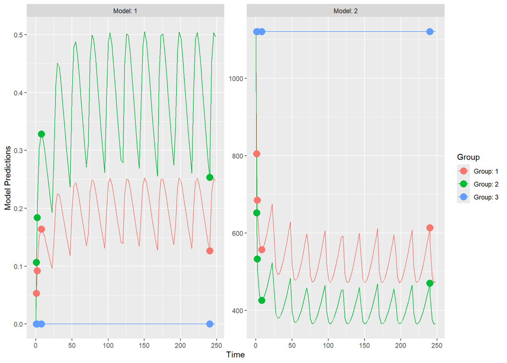

```r
##  create plot of model without variability
plot_model_prediction(babel.db,facet_scales="free")
```

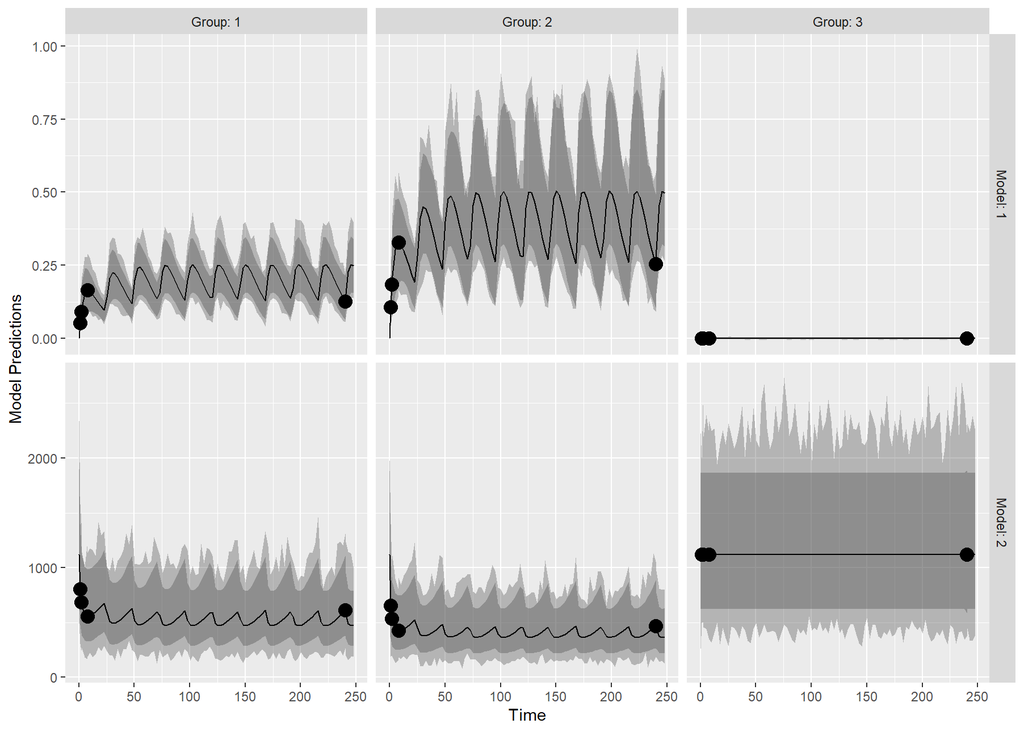

```r
##  create plot of model with variability
plot_model_prediction(babel.db,IPRED=T,DV=T,facet_scales="free",separate.groups=T)
```

## Design evaluation

The design evaluation function from PopED works seamlessly with the babelmixr2/PopED database. Notice that we are receiving the same results as in the classical PopED workflow.

```r
evaluate_design(babel.db)
```

```
## $ofv
## [1] 41.91255
##
## $fim
##                     tV           tKa           tCl           tE0         tImax
## tV        5.382083e-02   -8.55463621  -0.115087643  8.293963e-05    -0.2103527
## tKa      -8.554636e+00 3038.24916331 -14.769854183 -1.351406e-02   -69.0609687
## tCl      -1.150876e-01  -14.76985418  39.394916550  3.372827e-03    -7.0857453
## tE0       8.293963e-05   -0.01351406   0.003372827  4.403253e-04    -0.4017382
## tImax    -2.103527e-01  -69.06096865  -7.085745272 -4.017382e-01   821.9499010
## tIC50     3.704090e-01    5.89767910  16.302391331  1.181080e+00 -1818.6277839
## d_eta.v   0.000000e+00    0.00000000   0.000000000  0.000000e+00     0.0000000
## d_eta.ka  0.000000e+00    0.00000000   0.000000000  0.000000e+00     0.0000000
## d_eta.cl  0.000000e+00    0.00000000   0.000000000  0.000000e+00     0.0000000
## d_eta.e0  0.000000e+00    0.00000000   0.000000000  0.000000e+00     0.0000000
##                 tIC50      d_eta.v   d_eta.ka    d_eta.cl     d_eta.e0
## tV           0.370409    0.0000000   0.000000    0.000000    0.0000000
## tKa          5.897679    0.0000000   0.000000    0.000000    0.0000000
## tCl         16.302391    0.0000000   0.000000    0.000000    0.0000000
## tE0          1.181080    0.0000000   0.000000    0.000000    0.0000000
## tImax    -1818.627784    0.0000000   0.000000    0.000000    0.0000000
## tIC50     5030.928543    0.0000000   0.000000    0.000000    0.0000000
## d_eta.v      0.000000 1017.0362152 303.009671   12.339375    0.5721641
## d_eta.ka     0.000000  303.0096707 450.738937    2.396824    0.1852950
## d_eta.cl     0.000000   12.3393752   2.396824 3836.326714    2.5117794
## d_eta.e0     0.000000    0.5721641   0.185295    2.511779 2542.4091894
##
## $rse
##        tV       tKa       tCl       tE0     tImax     tIC50   d_eta.v  d_eta.ka
##  8.119842  9.968612  4.304635  7.076883  9.895340 39.478269 38.960998 58.523187
##  d_eta.cl  d_eta.e0
## 25.832775 22.036110
```

### Design optimization

#### Optimization of sample times

```r
# Optimization of sample times
# Note: The parallel option does not work well with Windows machines at this moment.
# Please set parallel = FALSE if you are working on a Windows machine
output <- poped_optim(babel.db, opt_xt = T, parallel = F)
```

```r
# Evaluate optimization results
summary(output)
```

```
## ===============================================================================
## FINAL RESULTS
## Optimized Sampling Schedule
## Group 1: Model 1:      1     10     10    240    241
## Group 1: Model 2:      0      1      1    246    246
## Group 2: Model 1:      1     10     10    240    241
## Group 2: Model 2:      0      1      1    246    246
## Group 3: Model 1:      1     10     10    240    241
## Group 3: Model 2:      0      1      1    246    246
##
## OFV = 45.44
##
## Efficiency:
##   ((exp(ofv_final) / exp(ofv_init))^(1/n_parameters)) = 1.423
##
## Expected relative standard error
## (%RSE, rounded to nearest integer):
##    Parameter     Values   RSE_0   RSE
##           tV       72.8       8     6
##          tKa       0.25      10     8
##          tCl       3.75       4     4
##          tE0   1.12e+03       7     5
##        tImax      0.807      10     5
##        tIC50     0.0993      39    22
##      d_eta.v       0.09      39    32
##     d_eta.ka       0.09      59    51
##     d_eta.cl     0.0625      26    26
##     d_eta.e0       0.09      22    22
##
## Total running time: 287.77 seconds
```

```r
get_rse(output$FIM,output$poped.db)
```

```
##        tV       tKa       tCl       tE0     tImax     tIC50   d_eta.v  d_eta.ka
##  6.330339  7.998091  4.297391  4.910302  4.536968 22.010463 32.326187 51.044557
##  d_eta.cl  d_eta.e0
## 26.335721 22.015047
```

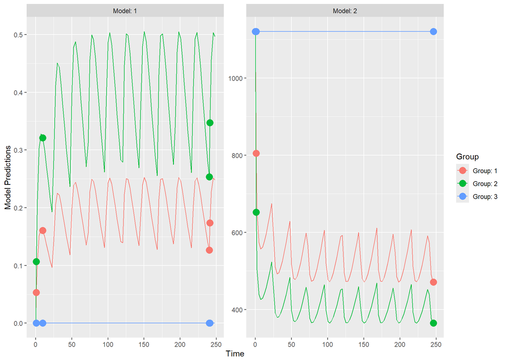

```r
plot_model_prediction(output$poped.db,facet_scales="free")
```

*End of Hand-on 2 - Design evaluation and optimization with PopED, babelmixr2 and nlmixr2 ACoP15 2024*